# Stats 102C Homework 4

Yiran Liu

11/18/2021

**Problem 1**

**a**

**b**

```r
trimmed_m <- function(k,Sample_size,B){

    #Input:
    # k indicates the level of trimmed means
    # Sample_size: Sample_size
    # B : number of iteration repeating the process of calculating theta hat

    #Output:
    # using Monte Carlo methods to estimate the MSE of the level k trimmed means
theta_hat_list = numeric()
    for(i in 1:B){
    x<- rcauchy(30)
    x<- sort(x)
    start_pos = k+1
    start_pos = Sample_size - k
    theta_hat <- 1/(Sample_size-2*k)*sum(x[start_pos:start_pos])
    theta_hat_list = c(theta_hat_list, theta_hat)}
    # Center of distribution should be used, which is 0
    return(sum((theta_hat_list - 0)^2)/B)
}
```

k = 1

```r
trimmed_m(1, 30,1000)
```

```
## [1] 0.4341542
```

k = 2

```r
trimmed_m(2, 30,1000)
```

```
## [1] 0.1123119
```

k = 3

```r
trimmed_m(3, 30,1000)
```

```
## [1] 0.02609849
```

k = 4

```r
trimmed_m(4, 30,1000)
```

```
## [1] 0.01295035
```

k = 5

```r
trimmed_m(5, 30,1000)
```

```
## [1] 0.009122182
```

**Problem 2**

**a**

```r
set.seed(123)
X = runif(1000)
theta = mean(3 * exp(-3 * X))
theta
```

```
## [1] 0.9543038
```

**b**

```r
set.seed(123)
theta_antithetic_mc = function(m = 10000){
  X = runif(m/2)
  Y_j = 3 * exp(-3 * X)
  Y_j_a = 3 * exp(-3 * (1-X))
  theta_antithetic = sum(Y_j + Y_j_a)/ m
  theta_antithetic
}
theta_antithetic_mc()
```

```
## [1] 0.9493707
```

**c**

Here is the integration of f with respect to x from interval 0 to 1  
1.5 - 3/(2 * e^2)  
Therefore, E[f(x)] = u = 1.5 - 3/(2 * e^2)

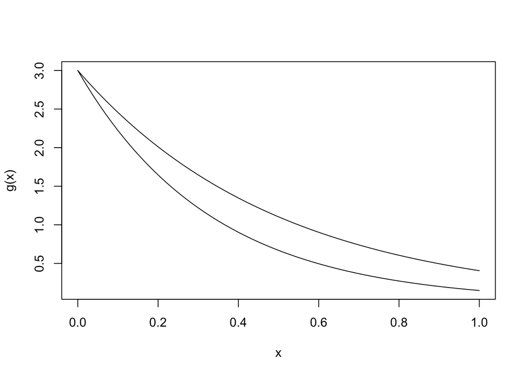

```r
set.seed(123)
f <- function(x) 3 * exp(-2 *x)
g <- function(x) 3 * exp(-3 *x)
curve(g)
curve(f,add = T)
```

```r
control_variate_mc = function(m, g_func){
  u = runif(m)
  B = f(u)
  A = g_func(u)
  a = -cov(A,B)/var(A)
  T1 = g_func(u)
  T2 = T1 + a * (f(u) - (1.5 - 1.5 * exp(-2)))
  c(mean(T2),var(T2))
}



ans = control_variate_mc(m = 10000, g_func = g)
ans[1]
```

```
## [1] 0.949556
```

**d**

We separate interval 0 to 1 into five stratum evenly.  
0 - 0.2  
0.2 - 0.4  
0.4 - 0.6  
0.6 - 0.8  
0.8 - 1.0

k = 5  
m = 50

```r
set.seed(123)
g <- function(x) 3 * exp(-3 *x)




   X_m1 = runif(50,0,0.2)
   X_m2 = runif(50,0.2,0.4)
   X_m3 = runif(50,0.4,0.6)
   X_m4 = runif(50,0.6,0.8)
   X_m5 = runif(50,0.8,1.0)
(mean(g(X_m1)) + mean(g(X_m2)) + mean(g(X_m3)) + mean(g(X_m4)) + mean(g(X_m5)))/5
```

```
## [1] 0.9453796
```

**e**

theoretical value  
Integrate 3 * e^-3x dx from 0 to 1, we get theta = 1 - e^-3 = 0.9502129

from (a), we have estimate of theta to be 0.9543038  
from (b), we have estimate of theta to be 0.9493707  
from (c), we have estimate of theta to be 0.949556  
from (d), we have estimate of theta to be 0.9453796

The estimates I got are pretty close to the theoretical value as you can see.

```r
# without any means of variance reduction
var(3 * exp(-3 * X))
```

```
## [1] 0.5912464
```

```r
#theta_antithetic
n = 50
MC1 = numeric(n)
for(i in 1:n){
  MC1[i] = theta_antithetic_mc()
}
var(MC1)
```

```
## [1] 1.355462e-05
```

```r
#control variate approach
ans[2]
```

```
## [1] 0.01524779
```

```r
#stratified sampling approach
1/(5 * 5 * 50) * (var(g(X_m1)) + var(g(X_m2)) + var(g(X_m3)) + var(g(X_m4)) + var(g(X_m5)))
```

```
## [1] 0.0001709932
```

The above output follows the order of the four methods I used from part a to part d above.

Indeed, without any means of variance reduction the theta hat from part a gives the biggest variance.  
The estimate of theta using the control variate approach gives the second biggest variance.  
The stratified sampling approach gives the third biggest variance.  
Antithetic variate approach gives the smallest variance.

**Problem 4**

**a**

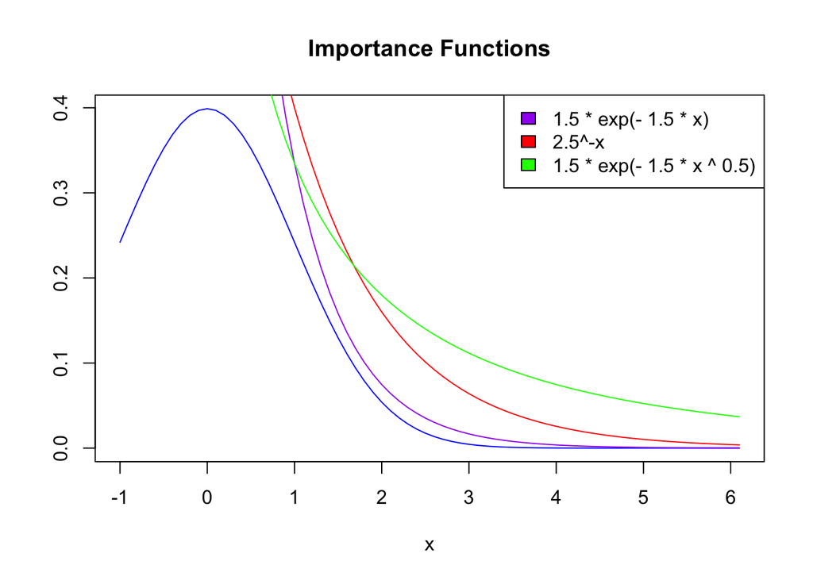

```r
x <- seq(-1,pi + 3,0.1)
plot(x, 1/(sqrt(2*pi)) * exp(-x^2/2),
main="Importance Functions",
ylab="",
type="l",
col="blue")

lines(x,  1.5 * exp(- 1.5 * x) , col = "purple")
lines(x,  2.5^-x , col = "red")
lines(x,  1.5 * exp(- 1.5 * x ^ 0.5) , col = "green")

legend("topright",
c("1.5 * exp(- 1.5 * x)","2.5^-x","1.5 * exp(- 1.5 * x ^ 0.5)"),
fill=c("purple","red","green")
)
```

As you can see from above, 1.5 * exp(- 1.5 * x), the function in purple should produce the smallest Var[theta hat] because it most mimics |g(x)|f(x).

**b**

```r
MC_IF <- function(c = 0.5){
  # Input:
  # c: user-defined positive constant
  # output:
  # compute a Monte Carlo estimate of theta using importance functions you proposed in (a).
  n = 10000
  x = rexp(n, rate = 1.5)
  x  = x[x > c]
  w = 1/(sqrt(2*pi) * 1.5) * exp(1.5 *x -0.5 * x^2)
  return(sum(w)/n)
}
```

**c**

```r
MC_IF(c = 0.5)
```

```
## [1] 0.3120613
```

```r
pnorm(q = 0.5,lower.tail = F)
```

```
## [1] 0.3085375
```

```r
MC_IF(c = 1)
```

```
## [1] 0.1592488
```

```r
pnorm(q = 1,lower.tail = F)
```

```
## [1] 0.1586553
```

```r
MC_IF(c = 2)
```

```
## [1] 0.02189491
```

```r
pnorm(q = 2,lower.tail = F)
```

```
## [1] 0.02275013
```

```r
MC_IF(c = 3)
```

```
## [1] 0.001148769
```

```r
pnorm(q = 3,lower.tail = F)
```

```
## [1] 0.001349898
```

As you can see from above, my estimates with the theoretical values for C = 0.5, 1, 2, 3 are all pretty close.

**Problem 5**

We separate interval 0 to 1 into five stratum evenly.  
0 - 0.2  
0.2 - 0.4  
0.4 - 0.6  
0.6 - 0.8  
0.8 - 1.0

```r
set.seed(123)
#first draw samples from f(x)

theta_list = numeric(1000)
for (i in 1:1000){
  u1 = runif(1000,0,0.2)
x1 = -log(1- (1-exp(-1))*u1)
theta1 = 1/1000 * sum((1 - exp(-1))/(1+x1^2))

u2 = runif(1000,0.2,0.4)
x2 = -log(1- (1-exp(-1))*u2)
theta2 = 1/1000 * sum((1 - exp(-1))/(1+x2^2))

u3 = runif(1000,0.4,0.6)
x3 = -log(1- (1-exp(-1))*u3)
theta3 = 1/1000 * sum((1 - exp(-1))/(1+x3^2))

u4 = runif(1000,0.6,0.8)
x4 = -log(1- (1-exp(-1))*u4)
theta4 = 1/1000 * sum((1 - exp(-1))/(1+x4^2))

u5 = runif(1000,0.8,1)
x5 = -log(1- (1-exp(-1))*u5)
theta5 = 1/1000 * sum((1 - exp(-1))/(1+x5^2))

theta = (theta1 + theta2 + theta3 + theta4 + theta5)/5
theta_list[i] = theta
}

mean(theta_list)
```

```
## [1] 0.5247977
```

```r
var(theta_list)
```

```
## [1] 8.549347e-08
```

```r
set.seed(123)
theta_list = numeric(1000)

for( i in 1:1000){
  u = runif(5000,0,1)
 x = -log(1- (1-exp(-1))*u)
 theta = 1/5000 * sum((1 - exp(-1))/(1+x^2))
 theta_list[i] = theta
}
mean(theta_list)
```

```
## [1] 0.5248078
```

```r
var(theta_list)
```

```
## [1] 1.824027e-06
```

As we can see from above, the estimated value for theta obtained by using stratified importance sampling is close to the estimated value for theta by only using importance sampling. However using stratified importance sampling, we get a smaller variance.